# TAREA 1

Barròn Paredes Ericka Ximena

Lunes 08 de Marzo del 2021

Naturaleza: La cebada es un cereal de gran importancia como alimento humano y del ganado, este grano ocupa el quinto lugar como de cultivo en el mundo, junto al trigo, el maíz y el arroz, la cebada forma el grupo de cereales “destacados” porque se puede plantar en terrenos poco fértiles y a diferentes alturas. Además, durante miles de años, se utilizó para fabricar pan, algo que en la actualidad ha sido sustituido por el trigo.

Valor de uso: La cerveza tiene su proceso que es un poco extenso pero lo que sabemos es que este proceso ocupa mano de obra y maquinaria ya que este proceso consta de 7 pasos los cuales son el malteado, molienda y maceración, filtración de mosto, cocción, fermentación de la cerveza, maduración y el envasado y este proceso dura aproximadamente 42 días y 11 horas.

Valor de cambio: La producción de cerveza en México en 2014 fue de 8.95 mil millones de litros, 6.1 % mayor con respecto al año previo. En 2014 se exportaron 1.7 mil millones de litros con un valor de 1,588 millones de dólares (mdd). Según cifras preliminares del Servicio de Información Agroalimentaria y Pesquera (SIAP), en el primer trimestre de 2015, el volumen exportado asciende a 440 millones de litros con un valor de 467 mdd. El principal destino de las exportaciones de cerveza es EE.UU. (72%), Chile (5%), Australia (5%), Canadá (4%), Reino Unido (2%), otros (12%). De acuerdo a datos de Cerveceros de México, la industria genera 55 mil empleos directos y 2.5 millones de indirectos

Valor: : Ya sea oscura o clara, la cerveza hecha en México la podemos encontrar alrededor del mundo. Actualmente, de una lista de 125 países, México ocupa a nivel internacional el 7° séptimo lugar como productor, el 1er lugar como exportador, y el 15° lugar como importador de cerveza.

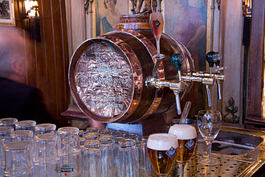

## Bibliografía

1. https://www.gob.mx/se/articulos/industria-de-la-cerveza-en-mexico
2. https://www.gob.mx/agricultura/articulos/cebada-alimento-del-cuerpo-y-del-alma